# Training, Sleep, and Recovery Dynamics in Recreational Runners: A Longitudinal Wearable Analytics Study

## 8 Fitness Trajectories

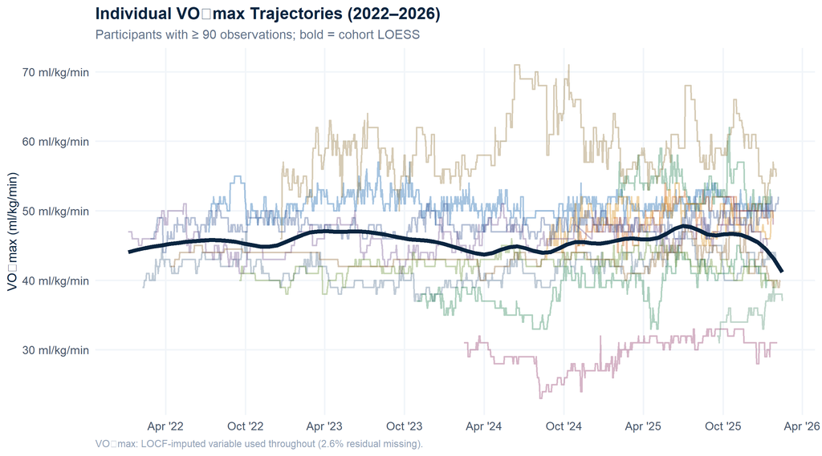

Figure 18: **Individual aerobic fitness trajectories over time.** Each thin coloured line traces one participant’s estimated VO₂max from 2022 to 2026. The bold dark curve shows the overall group trend smoothed across all participants. Only athletes with at least 90 recorded days are included.

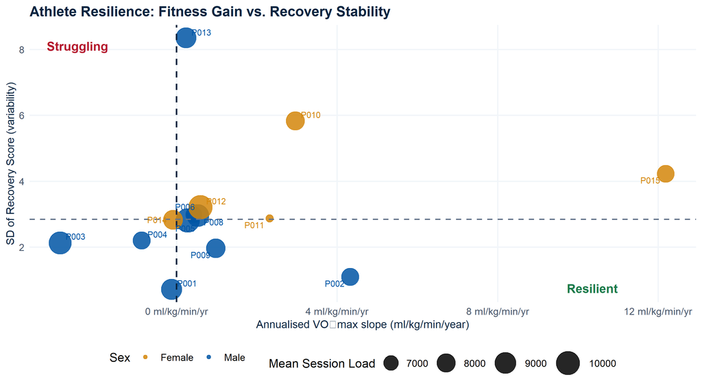

Figure 19: **Fitness improvement vs. recovery stability — one dot per athlete.** Moving right means the athlete improved their aerobic fitness over the study; moving up means their day-to-day recovery was more erratic. Dot size reflects average training volume; colour indicates sex (blue = Male, amber = Female). The dashed vertical line separates athletes who improved fitness (right) from those who did not (left). Quadrant labels summarise what each combination means.

The resilience scatter (Figure 19) reveals which athletes were able to simultaneously improve fitness while maintaining low recovery variability — the most desirable combination from a training efficiency standpoint. Athletes in the bottom-right “Resilient” quadrant tend to be those with lower training monotony (cross-referencing Table 4), suggesting that varied training stimuli facilitate both fitness gains and recovery stability. Athletes in the top-left “Struggling” quadrant, who show declining fitness alongside high recovery variability, merit investigation into training load management, sleep hygiene, and external stress factors.